# bayesOmic: Association analysis of genomic data using a Bayesian shared component model

Laura Balagué, Juan J Abellán, Carlos Abellán, Juan R González*

2020-03-15

# 1 Introduction

This document provides an overview of the `bayesOmic` package that will be available at Bioconductor (http://bioconductor.org/). The package implements a Bayesian approach for omic association studies. We propose a shared-component model to tease out the feature information (e.g. SNPs, CNVs, genes, transcripts, CpGs) that is common to cases and controls from the one that is specific to cases. This allows to detect the SNPs (bayesSNPassoc function) or any continuos feature (`bayesOmicAssoc` function) that show the strongest association with the disease. The model can nevertheless be applied to more than one disease. More detailed information about the model and assumptions are given in Abellan, Abellan, and Gonzalez (2010) and González, Abellán, and Abellán (2012) in the case of analyzing SNPs or CNVs, respectively. We illustrate how to analyze SNP data by using a synthetic data set of a targeted study (e.g. a selection of SNPs), GWAS data comparing different populations from 1000 Genomes project (To be supplied) and expression data (i.e. a RangedSummarizedExperiment object for an RNA-Seq experiment) on four human airway smooth muscle cell lines.

# 2 Getting started

The `bayesOmic` package uses JAGS, a program for analysis of Bayesian hierarchical models using Markov Chain Monte Carlo (MCMC) simulation Plummer and others (2003), to estimate model parameters. The current implementation of `bayesOmic` is based on JAGS version 4.3.0. JAGS has an R interface rjags that is used by the package (rjags version 4-9).

The development version of `bayesOmic` can be installed from our GitHub repository

```r
library(devtools)
install_github("isglobal-brge/bayesOmic")
```

Then, the package is loaded as usual

```r
library(bayesOmic)
```

# 3 Analysis of SNP data: small datasets

Let us illustrate how to apply our model to a GWAS study as described in Abellan, Abellan, and Gonzalez (2010). The examples correspond to a simulated data including information about 72 SNPs. It contains information of 800 individuals divided in 4 populations: controls and 3 type of cases (M1, M2, and M3). We simulated SNPs that are specific from gene 1 to be associated with M1 and SNPs from gene 3 to M3.

Let us start by describing how to get the data into R

## 3.1 The data

Data can be imported from a text file or can be loaded using snpMatrix package (to be supplied). We provide a simulated example that can be loaded by typing:

```r
data(sim.data)
```

This is a simulated data having 72 SNPs and one column with case/control status

```r
dim(sim.data)
[1] 800  73
sim.data[1:5, 1:5]
     caco snp74519580 snp30066728 snp32588600 snp57373945
1 Control          AB          AA          BB          AB
2 Control          AB          AB          AA          AB
3 Control          AA          AB          AB          AA
4 Control          AB          AB          AA          AA
5 Control          AB          AA          AA          AA
```

We can use `SNPassoc` package to prepare the data to perform data analysis.

```r
library(SNPassoc)
ii <- grep("snp", colnames(sim.data))
SNPs <- setupSNP(sim.data, colSNPs = ii, sep="")
```

## 3.2 Model parameter estimates

The model can be fitted by using the function `bayesSNPassoc` as follows:

```r
mod <- bayesSNPassoc( ~ caco, data=SNPs, n.cores=3)
```

The function `bayesSNPassoc` prepares the data (i.e, it aggregates the number of rare alleles by the grouping variable). Then the function calls `jags.parfit` from `dclone` package. The argument `n.cores` indicates the number of cores used to fit the model if multiple processors are available. By default `n.cores=1`.

We have set up the following default arguments to be passed through rjags functions:

```r
args(bayesSNPassoc)
function (formula, data, chr, call.rate = 0.9, min.freq = 0.05,
    sig.level = 0.05, method = "JAGS", n.iter.burn.in = 1000,
    n.adapt = 100, n.iter = 5000, thin = 5, n.chain = 2, n.cores = 1,
    ...)
NULL
```

Notice that other arguments realated to MCMC estimation using JAGS can be passed through this function. More details about them can be obtained at http://calvin.iarc.fr/ martyn/software/jags/.

The function also has two arguments to perform a simple quality control. The argument `call.rate` stands for the call rate of a given individual (e.g. proportion of non-missing SNPs, default is 0.9) and `min.freq` provides the minimum allele frequency allowed for a given SNP (default is 0.05).

## 3.3 Checking convergence

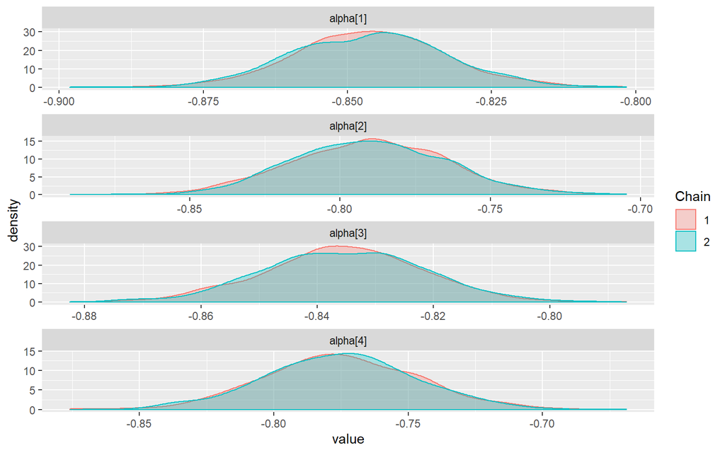

Figure 1: Chains convergence of `alpha` parameter for SNP model of ‘sim  
data’.

```r
checkConvergence(mod)
```

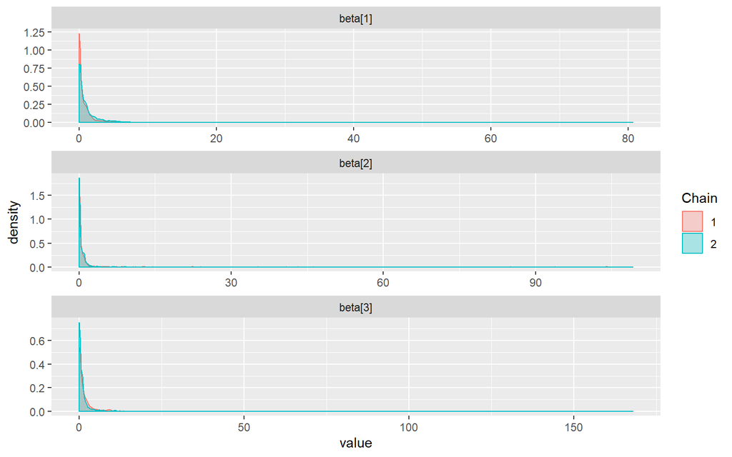

```r
checkConvergence(mod, parameter = "beta")
```

The trace plot can be obtained by

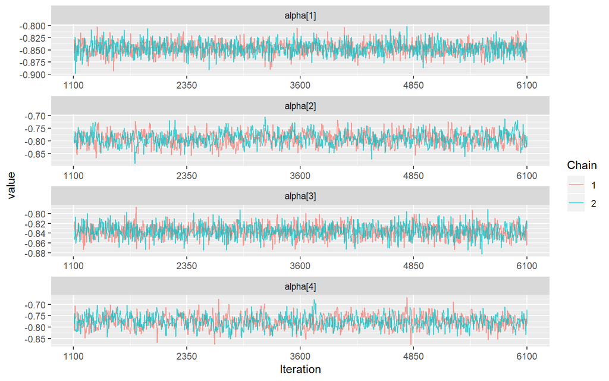

```r
checkConvergence(mod, type = "trace")
```

The JAGS estimation can be very time consuming. INLA (Integrated Nested Laplace Approximation) can be used instead

```r
mod.inla <- bayesSNPassoc( ~ caco , data=SNPs, method="INLA")
```

## 3.4 Results

Model parameters (intercept and shared component) can be obtained by using print function:

```r
mod

 Intercepts (alpha):
                         2.5%        50%      97.5%
Control -0.8461409 -0.8719641 -0.8459009 -0.8198052
M1      -0.7903065 -0.8387620 -0.7904050 -0.7396626
M2      -0.8354868 -0.8622423 -0.8355158 -0.8093377
M3      -0.7751555 -0.8310618 -0.7754204 -0.7180044

 Coefficients of shared components (beta):
                     2.5%        50%    97.5%
M1 1.0199044 4.140429e-11 0.23611807 5.579866
M2 0.7595323 1.988722e-10 0.07656304 3.306545
M3 1.4483893 1.023348e-09 0.35855862 9.212706

 Use 'getSpecific()' and 'getShared()' functions to get specific or shared components, respectively.
```

```r
mod.inla

 Intercepts (alpha):
                   mean 0.0003472222quant   0.5quant 0.9996528quant
alphaControl -0.8458107        -0.8894580 -0.8458110     -0.8021242
alphaM1      -0.7710769        -0.8602661 -0.7710362     -0.6826097
alphaM2      -0.8352583        -0.8790588 -0.8352586     -0.7914252
alphaM3      -0.7517331        -0.8452051 -0.7516934     -0.6589385

 Coefficients of shared components (beta):
NULL

 Use 'getSpecific()' and 'getShared()' functions to get specific or shared components, respectively.
```

On the other hand, specific components can be visualize by:

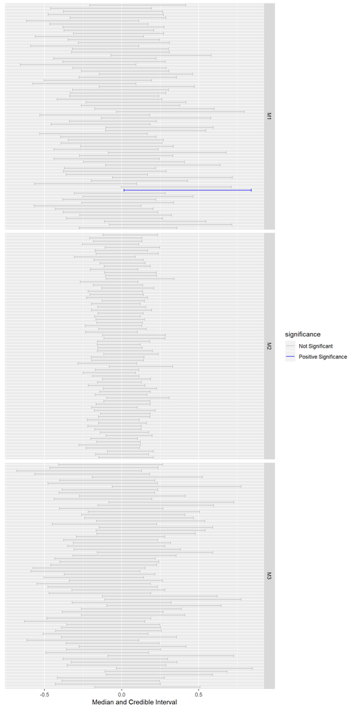

```r
plot(mod, type="specific")
```

and

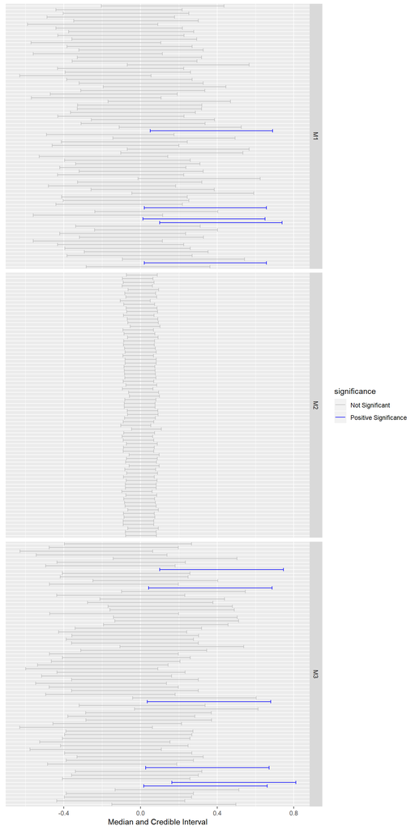

```r
plot(mod.inla, type = "specific")
```

respectively.

Finally, a hierarchical clustering can be performed by using the predicted probabilities by typing:

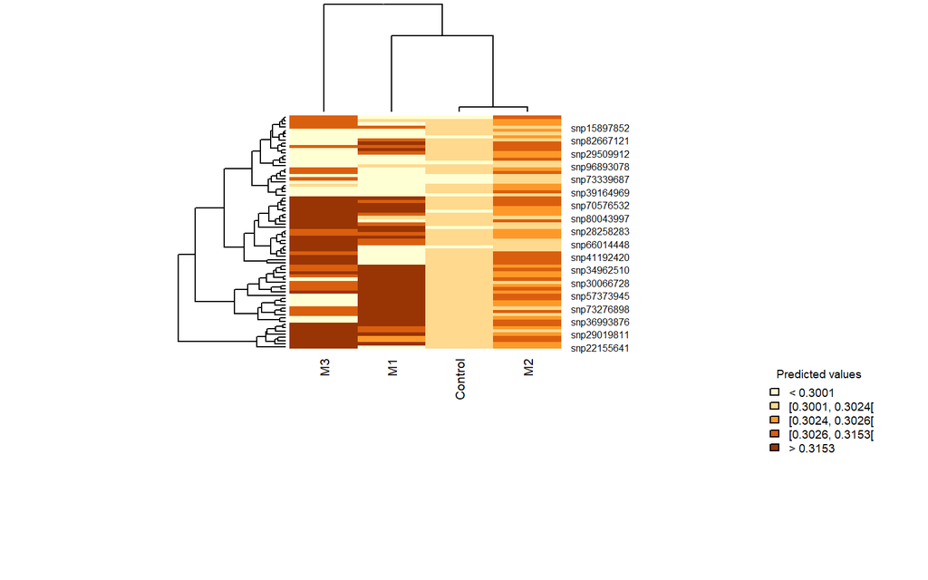

```r
makeHeatmap(mod.inla)
```

The figure shows a Heatmap were we can observe that groups M1 and M3 are different from controls and group M2.